# Using `BRcal` to Assess and Embolden Probability Forecasts

### Using `LLO()` with MLEs or Boldness-Recalibration Estimates

Another example of when users may want to use `LLO()` directly is in getting the MLE recalibrated set. We have already demonstrated how to go about this using `mle_recal()`. Alternatively, you can get the MLE recalibrated set manually by first getting the MLEs from another function (such as `bayes_ms()` or `llo_lrt()`) and then passing those as `delta` and `gamma` in `LLO()`. This may be useful in cases where you have large data and finding the MLEs is slower than desired. If you already have the MLEs from a previous function call to `bayes_ms()` or `llo_lrt()` then you don’t need to take the time to re-solve for the MLEs. Additionally, this approach serves as a good alternative to using `mle_recal()` with `probs_only=TRUE`.

In the example below, we’ll use the MLEs for FiveThirtyEight’s predictions we saved from `bayes_ms()` earlier on and pass those to `LLO()`. Notice the probabilities below are identical to those we got from `mle_recal()`.

```r
hockey$x_mle <- LLO(x=hockey$x, delta=bt538$MLEs[1], gamma=bt538$MLEs[2])
hockey$x_mle
>   [1] 0.5633646 0.6814612 0.5628440 0.5117077 0.5675526 0.4223768 0.3802169
>   [8] 0.4748424 0.5231574 0.3000678 0.5266953 0.5292678 0.4957091 0.5647970
>  [15] 0.6538569 0.4845104 0.4090460 0.5792843 0.6937447 0.6000152 0.3961722
...

> [855] 0.7210362 0.6593455 0.4586214 0.7750603 0.5841900 0.4826292 0.4080026
> [862] 0.6701504 0.6561462 0.4814185 0.7421488 0.6786381 0.3255808 0.4814569
```

Let’s visualize what this LLO-adjustment looks like by plotting the original probabilities (`hockey$x`) on the x-axis and the MLE recalibrated probabilities (`hockey$x_mle`) on the y-axis. Note that the points below are the actual observations and the curve represents how any prediction along the 0-1 range would behave under `delta`=0.9453966 and `gamma`=1.400573.

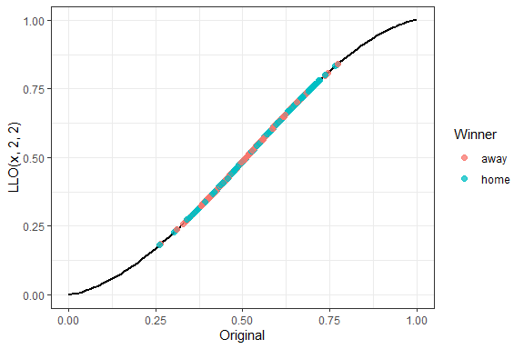

```r
# plot original vs LLO-adjusted via MLEs
ggplot2::ggplot(data=hockey, mapping=aes(x=x, y=x_mle)) +
  stat_function(fun=LLO,
                args=list(delta=bt538$MLEs[1],
                          gamma=bt538$MLEs[2]),
                geom="line",
                linewidth=1,
                color="black",
                xlim=c(0, 1)) +
  geom_point(aes(color=winner), alpha=0.75, size=2) +
  lims(x=c(0,1), y=c(0,1)) +
  labs(x="Original", y="LLO(x, 2, 2)", color="Winner") +
  theme_bw()
```

Similarly, say you have already obtained boldness-recalibration estimates but did not save the vector of boldness-recalibrated probabilities. You can use `LLO()` to boldness-recalibrate with your estimates without taking the time to let the optimizer in `brcal()` re-solve for these estimates.

In the example below, we’ll use the 90% boldness-recalibration estimates for FiveThirtyEight’s predictions we saved from `brcal()` earlier on and pass those to `LLO()`. This essentially achieves the same probabilities in `probs` returned by `brcal()` by LLO-adjusting via the returned boldness-recalibration parameters in `BR_params` returned by `brcal()`.

```r
LLO(x=hockey$x, br90$BR_params[1], br90$BR_params[2])
>   [1] 0.57521324 0.73683075 0.57447030 0.50109237 0.58118451 0.37458745
>   [7] 0.31759475 0.44828613 0.51755392 0.21761392 0.52264063 0.52633875
>  [13] 0.47812060 0.57725659 0.70072899 0.46208535 0.35630619 0.59785587
...

> [859] 0.60479909 0.45939663 0.35488466 0.72219848 0.70377197 0.45766716
> [865] 0.81088037 0.73320058 0.24804606 0.45772207
```

### Extreme Value of `delta` or `gamma`

As previously mentioned, using extreme values of `delta` or `gamma` can cause instabilities. For example, let’s see what happens when when we set `delta=2`, `gamma=1000`. In the plot below, we show the original probabilities on the x-axis and the LLO-adjusted probabilities via `delta=2`, `gamma=1000` on the y-axis. Notice that nearly all predictions were pushed to approximately 0 or 1.

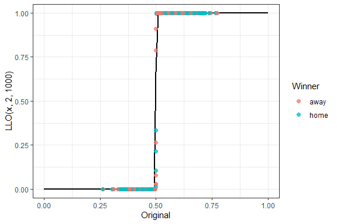

```r
# LLO-adjust using delta=2, gamma=1000
hockey$x2 <- LLO(hockey$x, delta=2, gamma=1000)

# plot original vs LLO-adjusted via 2,2
ggplot2::ggplot(data=hockey, mapping=aes(x=x, y=x2)) +
  stat_function(fun=LLO,
                args=list(delta=2, gamma=1000),
                geom="line",
                linewidth=1,
                color="black",
                xlim=c(0, 1)) +
  geom_point(aes(color=winner), alpha=0.75, size=2) +
  lims(x=c(0,1), y=c(0,1)) +
  labs(x="Original", y="LLO(x, 2, 1000)", color="Winner") +
  theme_bw()
```

While this didn’t cause problems plotting the LLO curve, there are cases in this package where probabilities very close to 0 or 1 will cause instability and possibly even break the code. With this in mind, we do have safeguard in place to keep predictions from getting to close (numerically speaking) to 0 or 1, which is discussed further in Specifying `epsilon`.

## Specifying `epsilon`

When probability predictions that are “too close” to 0 or 1, calculations using the log likelihood become unstable. This is due to the fact that the logit function is not defined at 0 and 1. To mitigate this instability, we use `epsilon` to specify how close is “too close”. For values in `x` that are less than `epsilon` (i.e. too close to zero), these are replaced with `epsilon`. For values in `x` greater than `1 - epsilon` (i.e. too close to 1), these are replaced with `1 - epsilon`. Naturally, `epsilon` must take on a value between 0 and 1, but it is recommended that this be a very small number. By default, we use `.Machine$double.eps`.

In this example with the `hockey` data, there are no values close to 0 or 1 in `x` or `rand`, so `epsilon` is not used at all.

## Specifying `event`

Throughout this package, the functions assume by default that `y` is a vector of 0s and 1s where a 1 represents a “event” and 0 represents a “non-event”. Additionally, these functions expect that the probabilities in `x` are the probabilities of “event” at each observation. While switching the labels of “event” and “non-event” will not change the fundamental conclusions, it is good practice to make sure `event` is defined properly. However, there may be cases where you want to pass a binary vector of outcomes that are not defined as 0s and 1s. To define which of the two values in `y` should be considered a “success” or the event of interest, users may set argument `event` to that value.

For example, let’s use the column `winner` from the `hockey` dataset as our vector of binary outcomes instead of `y` in `bayes_ms()`. We can do this by specifying `event = "home"`. We’ll continue to set `optim_details=FALSE` for easier reading of the output.

```r
bayes_ms(hockey$x, hockey$winner, event="home", optim_details=FALSE)
> $Pmc
> [1] 0.5
>
> $BIC_Mc
> [1] 1148.637
>
> $BIC_Mu
> [1] 1157.902
>
> $BF
> [1] 0.009730538
>
> $posterior_model_prob
> [1] 0.9903632
>
> $MLEs
> [1] 0.9453966 1.4005730
```

As expected, the results are identical to our previous call.

Maybe you want to approach this problem from the perspective of an event being a home team loss. To do so, you need to pass the predicted probabilities of a home team loss as `x = 1 - hockey$x`, and specify which value in `y` is an event via `event=0` for `y=hockey$y`…

```r
bayes_ms(1-hockey$x, hockey$y, event=0, optim_details=FALSE)
> $Pmc
> [1] 0.5
>
> $BIC_Mc
> [1] 1148.637
>
> $BIC_Mu
> [1] 1157.902
>
> $BF
> [1] 0.009730605
>
> $posterior_model_prob
> [1] 0.9903632
>
> $MLEs
> [1] 1.057957 1.401514
```

… or `event="away"` for `hockey$winner`.

```r
bayes_ms(1-hockey$x, hockey$winner, event="away", optim_details=FALSE)
> $Pmc
> [1] 0.5
>
> $BIC_Mc
> [1] 1148.637
>
> $BIC_Mu
> [1] 1157.902
>
> $BF
> [1] 0.009730605
>
> $posterior_model_prob
> [1] 0.9903632
>
> $MLEs
> [1] 1.057957 1.401514
```

Note that we get the same results using either specification. Additionally, the posterior model probability is the same as when we considered event to be a home team win, as one might expect with binary event predictions.

## Visualizing Posterior Model Probability as a Function of $\delta$ and $\gamma$ via `plot_params()`

The goal of the `plot_params` function is to visualize how the posterior model probability changes under different recalibration parameters, as this is used in boldness-recalibration. Let’s see what the default version of this plot looks like with FiveThirtyEight’s data.

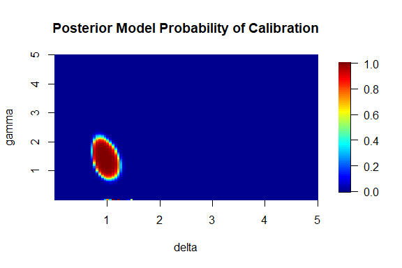

```r
plot_params(hockey$x, hockey$y)
> Warning in get_zmat(x = x, y = y, Pmc = Pmc, len.out = k, lower = c(dlim[1], :
> There may be innaccuracies near gamma=0
```

You might immediately notice the imagine is grainy and unnecessarily small. In the following sections, we will demonstrate how to fix these issues and make further adjustments via arguments in `plot_params()`.

### Setting bounds and grid density

To adjust the grid of $\delta$ and $\gamma$ values, we can use `dlim` and `glim` to “zoom in” on the area of non-zero posterior model probabilities. Let’s reduce the range of $\delta$ and $\gamma$ so we can better visualize the area of non-zero posterior model probability of calibration.

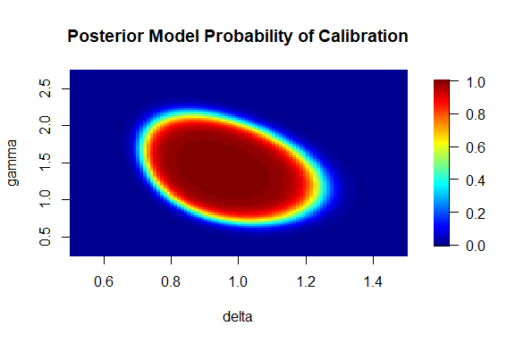

```r
plot_params(hockey$x, hockey$y, dlim=c(0.5, 1.5), glim=c(0.25, 2.75))
```

Next, we can use `k` to form a denser grid (and thus a smoother plotting surface). However, it’s important to note that the larger `k` values used, the slower this plot will generate.

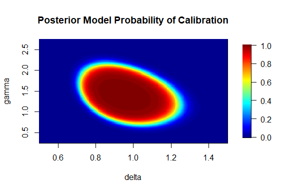

```r
plot_params(hockey$x, hockey$y, k=200, dlim=c(0.5, 1.5), glim=c(0.25, 2.75))
```

### Saving and Reusing `z`

Once you’ve settled on the bounds for $\delta$ and $\gamma$ you want to plot and the density of the grid via `k`, you can save the underlying matrix of posterior model probabilities to reuse while making minor plot adjustments. This will save you the hassle of having to recalculate these values, which is where the bottleneck on time occurs. To save this matrix, set `return_z=TRUE` and store the returned list from `plot_params()`.

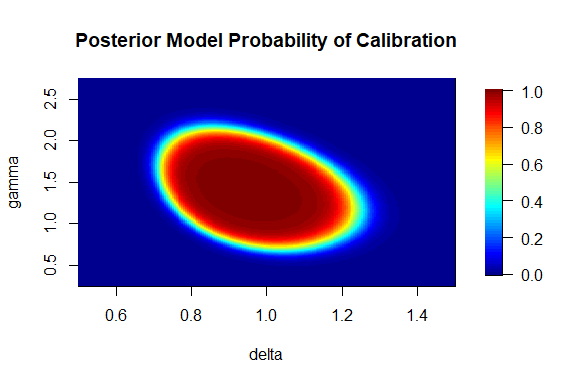

```r
zmat_list <- plot_params(hockey$x, hockey$y, k=200, dlim=c(0.5, 1.5), glim=c(0.25, 2.75),
                         return_z = TRUE)
```

The returned list is printed below. Note that the matrix is the first entry in the list named `z`. Additionally, the bounds passed via `dlim` and `glim`, and `k` are returned as a reminder of what values were used to construct `z`.

```r
zmat_list
> $z
>                           0.25 0.262562814070352 0.275125628140704
> 0.5               7.232601e-35      1.480850e-34      3.016613e-34
> 0.505025125628141 3.785684e-34      7.721926e-34      1.567085e-33
...

> $dlim
> [1] 0.5 1.5
>
> $glim
> [1] 0.25 2.75
>
> $k
> [1] 200
```

While it’s a little hard to see what `z` looks like in the output above, below shows that `z` is a 200 by 200 matrix (where 200 is the grid size set by `k`). The rows and columns are named based on the value of $\delta$ and $\gamma$ for which the posterior model probability was calculated.

```r
class(zmat_list$z)
> [1] "matrix" "array"
dim(zmat_list$z)
> [1] 200 200
```

Now we can reuse the matrix to adjust the plot by passing `zmat_list$z` to `z` in `plot_params()`. However, this trick is only useful so long as you do not expand the bounds over which you want to plot. Below shows the same `z` matrix plotted on (1) the same range, (2) a smaller range, and (3) a larger range than over which is was calculated. The white that appears in the third frame reflects the fact that the posterior model probability was not calculated for those grid cells since they are outside of the original bounds.

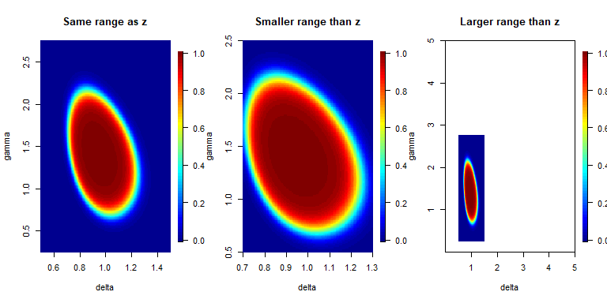

```r
par(mfrow=c(1,3))
plot_params(z=zmat_list$z, k=200, dlim=c(0.5, 1.5), glim=c(0.25, 2.75), main="Same range as z")
plot_params(z=zmat_list$z, k=200, dlim=c(0.7, 1.3), glim=c(0.5, 2.5), main="Smaller range than z")
plot_params(z=zmat_list$z, k=200, dlim=c(1e-04, 5), glim=c(1e-04, 5), main="Larger range than z")
```

We’ll continue to use this trick throughout to reduce plotting time.

### Adding contours and using `countors_only=TRUE`

To add contours at specific levels of the posterior model probability of calibration, users can specify these levels in a vector via `t_levels`. Below, we add contours at t = 0.95, 0.9, and 0.8. See (Passing Additional / Different Arguments to `image.plot()` and `contour()`)[#contour_opts] for guidance on adjusting the contours (i.e. changing color, line width, labels, etc).

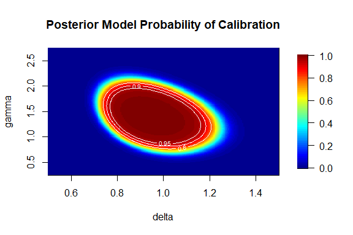

```r
plot_params(z=zmat_list$z, t_levels=c(0.95, 0.9, 0.8),
            k=200, dlim=c(0.5, 1.5), glim=c(0.25, 2.75))
```

To plot the contour surface without the color background, users should specify `contours_only=TRUE` as shown below. We’ll also add a few more contour levels.

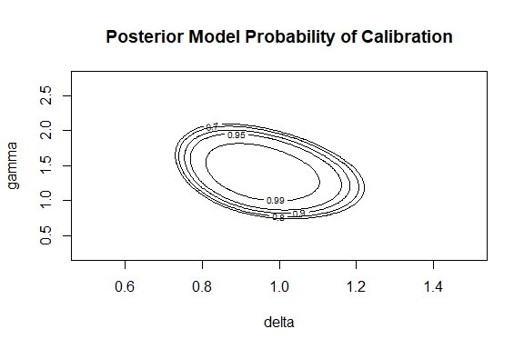

```r
plot_params(z=zmat_list$z, t_levels=c(0.99, 0.95, 0.9, 0.8, 0.7),
            k=200, dlim=c(0.5, 1.5), glim=c(0.25, 2.75), contours_only=TRUE)
```

### Passing Additional / Different Arguments to `image.plot()` and `contour()`

While `plot_params()` obscures the call to `image.plot()` and `contour()`, we allow users to leverage their full capabilities via arguments `imgplt_options` and `contour_options`. To pass additional arguments to `image.plot()` and `contour()`, users can create a list whose entries match the names of the arguments in these functions and pass them to `imgplt_options` and `contour_options`, respectively.

For example, below we can move the legend to appear horizontally below the plot using argument `horizontal = TRUE` in `image.plot()`. Additionally, we’ll reduce the number of colors used for plotting via `nlevel=10` and add a legend label via `legend.lab`. Notice how these are passed as a list to `imgplt_options`.

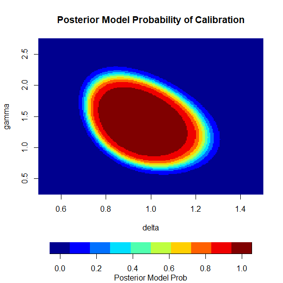

```r
plot_params(z=zmat_list$z, k=200, dlim=c(0.5, 1.5), glim=c(0.25, 2.75),
            imgplt_options=list(horizontal = TRUE, nlevel=10, legend.lab="Posterior Model Prob"))
```

We can also pass additional arguments to `contour()` via `contour_options`. Below, we’ll draw contours at t = 0.99 and 0.1. To make them dotted lines instead of solid, we’ll use `lty="dotted"`, we’ll change the contour color to hot pink, and we’ll increase the line width using `lwd=2`.

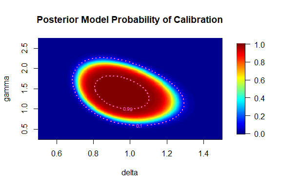

```r
plot_params(z=zmat_list$z, k=200, dlim=c(0.5, 1.5), glim=c(0.25, 2.75), t_levels = c(0.99, 0.1),
            contour_options=list(lty = "dotted", col="hotpink", lwd=2))
```

## Visualizing Recalibrated Probability Forecasts via `lineplot()`

The goal of the `lineplot` function is to visualize how predicted probabilities change under different recalibration parameters. By default this function shows changes in the original probabilities to the MLE recalibrated probabilities. Let’s see what this looks like with the FiveThirtyEight `hockey` data.

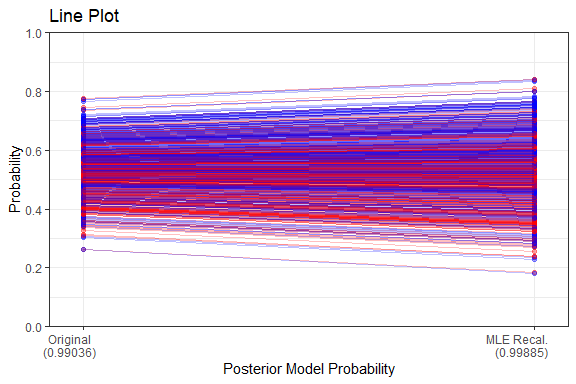

```r
lineplot(x=hockey$x, y=hockey$y)
```

Note that this function leverages the flexibility of the `ggplot2` package, so cosmetic modification and how the plot is returned is a little different than `plot_params`. We will demonstrate this throughout the following sections.

### Specifying Levels of Boldness-Recalibration via `t_levels`

```r
lineplot(x=hockey$x, y=hockey$y, t_levels = c(0.95, 0.9, 0.8))
```

[output not shown]

### Saving and reusing `df`

While the time expense of `lineplot` isn’t as high as `plot_params`, there is still a call to `optim` for MLE recalibration and a call to `nloptr` for each level of boldness-recalibration. Similar to returning the `z` matrix in `plot_params`, users of `lineplot` can specify `return_df` to return the underlying dataframe used to construct the plot.

By default, `return_df=FALSE` and `lineplot()` only returns the `ggplot` object of the lineplot. When `return_df=TRUE`, a list is returned with two entries: (1) `plot` which is the `ggplot` object of the lineplot and (2) `df` which is the underlying dataframe. The code below shows how to specify `return_df=TRUE` and saved the returned list.

```r
lp <- lineplot(x=hockey$x, y=hockey$y, return_df = TRUE, t_levels = c(0.95, 0.9, 0.8))
```

To extract the plot, we can use the following code.

```r
lp$plot
```

[output not shown]

We can also extract the dataframe using `lp$df`. The first and last few rows of the dataframe plus a summary of the dataframe are printed below. Notice there are 6 columns, here are their brief descriptions (more details below):

- `probs`: the values of each predicted probability under each set
- `outcome`: the corresponding outcome for each predicted probability of calibration
- `post`: the posterior model probability of the set as a whole
- `id`: the id of each probability used for mapping observations between sets
- `set`: the set with which the probability belongs to
- `label`: the label used for the x-axis in the lineplot

```r
lp$df
>           probs outcome      post  id       set                  label
> 1    0.55528238       1 0.9903632   1  Original   Original \n(0.99036)
> 2    0.64177575       1 0.9903632   2  Original   Original \n(0.99036)
> 3    0.55490924       1 0.9903632   3  Original   Original \n(0.99036)
> 4    0.51837525       0 0.9903632   4  Original   Original \n(0.99036)
> 5    0.55828545       0 0.9903632   5  Original   Original \n(0.99036)
> 6    0.45427667       0 0.9903632   6  Original   Original \n(0.99036)
...

> 4336 0.45558625       1 0.8000000 864   80% B-R         80% B-R\n(0.8)
> 4337 0.81615909       1 0.8000000 865   80% B-R         80% B-R\n(0.8)
> 4338 0.73767174       1 0.8000000 866   80% B-R         80% B-R\n(0.8)
> 4339 0.24187950       0 0.8000000 867   80% B-R         80% B-R\n(0.8)
> 4340 0.45564257       0 0.8000000 868   80% B-R         80% B-R\n(0.8)
```

```r
summary(lp$df)
>      probs         outcome       post              id               set
>  Min.   :0.09135   0:2025   Min.   :0.8000   Min.   :  1.0   80% B-R  :868
>  1st Qu.:0.43415   1:2315   1st Qu.:0.9000   1st Qu.:217.8   90% B-R  :868
>  Median :0.53261            Median :0.9500   Median :434.5   95% B-R  :868
>  Mean   :0.53226            Mean   :0.9278   Mean   :434.5   MLE Recal:868
>  3rd Qu.:0.63269            3rd Qu.:0.9904   3rd Qu.:651.2   Original :868
>  Max.   :0.91671            Max.   :0.9989   Max.   :868.0
>                   label
>  Original \n(0.99036)  :868
>  MLE Recal. \n(0.99885):868
>  95% B-R\n(0.95)       :868
>  90% B-R\n(0.9)        :868
>  80% B-R\n(0.8)        :868
>
```

The `probs` column contains each set of predicted probabilities that are plotted (i.e. the original, MLE recalibrated, and each set of boldness-recalibrated probabilities). The `outcome` column contains the corresponding outcome for each value in `probs`. Each set of probabilities and outcomes are essentially “stacked” on top of each other. The `id` column contains a unique id for each observation to map how observations change between sets. This essentially tells the plotting function how to connect (with line) the same observation as is changes from the original set to MLE- or boldness-recalibration. The `set` column contains a factor for which set that observation belongs to. The `post` column contains the value of the posterior model probability for the set as a whole, so this value will be the same for all observations in the same set. Lastly, the `label` column is a string that is used to label the x-axis for each set in the lineplot and is also the same for all observations in a set.

Since this dataframe has each set of probabilities stacked, the number of rows in the dataframe will be $\text{# of sets } \times n$, where $n$ is the number of observations per set. For example, in the data frame above, there are 5 sets (original, MLE, 95%, 90%, and 80% boldness-recalibration) with 868 observations total. So the length of the dataframe is 5 * 868 = 4340. This is confirmed below.

```r
nrow(lp$df)
> [1] 4340
```

Now with this dataframe saved, we can pass it back via `df` without needing to specify `x` or `y` and we get the same plot as before, but much more quickly. This functionality makes it easier to make cosmetic adjustments to your plot without needing to wait for computations under the hood.

```r
lineplot(df=lp$df, t_levels=c(0.95, 0.9, 0.8))
```

[output not shown]

Users can also choose to omit specific boldness-recalibration sets even if they are included in `df`. In the code below, we omit the 90% and 80% boldness-recalibrated sets by only setting `t_levels=0.95`.

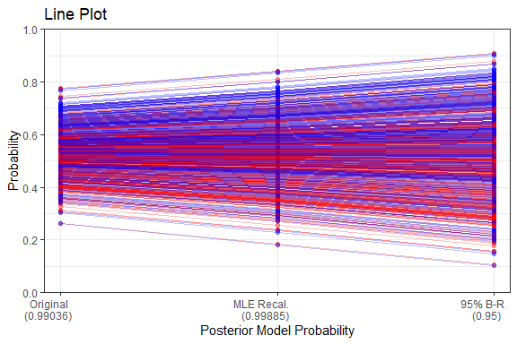

```r
lineplot(df=lp$df, t_levels=c(0.95))
```

### Omitting the Original or MLE-Recalibrated sets from plotting via `plot_original` and `plot_MLE`

To omit either the original set or the MLE-recalibrated set from plotting, users can specify `plot_original=FALSE` or `plot_MLE=FALSE`, respectively. Below is an example of omitting the original set by setting `plot_original=FALSE` while plotting the MLE-recalibrated and boldness-recalibration sets returned in `df` above.

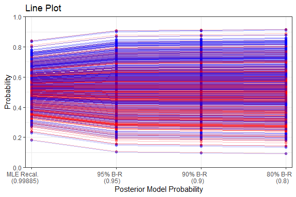

```r
lineplot(df=lp$df, t_levels=c(0.95, 0.9, 0.8), plot_original=FALSE)
```

### Cosmetic Adjustments

A key difference in how this plot is created compared to `plot_params()` is that it uses `ggplot2` instead of base `R` graphics. Users of `lineplot()` have quite a few options for making cosmetic changes to these plots. The first set of options we’ll discuss are those related to the points and lines already present on the lineplot. To modify the appearance of the points, users can pass options to `geom_point()` via a list to `ggpoint_options`. For example, the code below shows how to change the shape and size of the points.

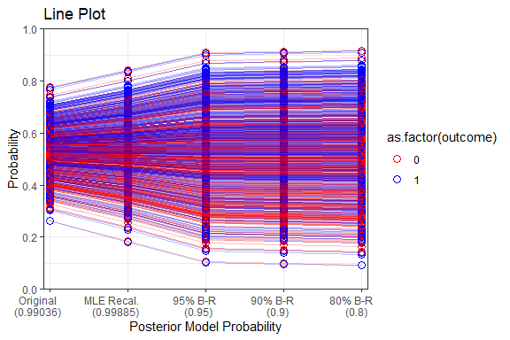

```r
lineplot(df=lp$df, t_levels=c(0.95, 0.9, 0.8), ggpoint_options=list(size=3, shape=1))
```

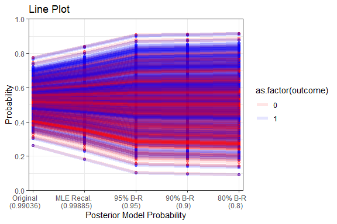

```r
lineplot(df=lp$df, t_levels=c(0.95, 0.9, 0.8), ggline_options=list(linewidth=2, alpha=0.1))
```

An important thing to note about these two options is that their purpose is solely for adjustments that are not part of the `aes` statement in `geom_point()` or `geom_line()`. Should users specify `aes` options via `ggpoint_options` or `ggline_options`, this will cause `ggplot()` to create a new layer of points or lines on top of those following the default settings we use under the hood.

Another option for making cosmetic adjustments is to use the convention of `ggplot2` and add additional `ggplot2` functions to the returned lineplot using `+`. For example, the code below shows how we could add the `scale_color_manual()` function to our plot to change the colors of the points and lines. Notice that `ggplot2` throws a warning about another color scale already being present. This is because under the hood we have already specified the default color scheme to be red and blue. A similar warning may appear in any case where a user adds a function that is already present in our original construction of the lineplot.

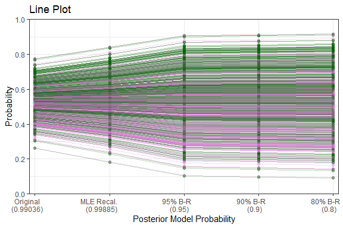

```r
lineplot(df=lp$df, t_levels=c(0.95, 0.9, 0.8)) +
  scale_color_manual(values = c("orchid", "darkgreen"))
> Scale for colour is already present.
> Adding another scale for colour, which will replace the existing scale.
```

### Thinning

Another strategy to save time when plotting is to reduce, or “thin”, the amount of data plotted. When sample sizes are large, the plot can become overcrowded and slow to plot. We provide three options for thinning:

- `thin_to`: the observations in (x,y) are randomly sampled without replacement to form a set of size `thin_to`
- `thin_prop`: the observations in (x,y) are randomly sampled without replacement to form a set that is `thin_prop` * 100% of the original size of (x,y)
- `thin_by`: the observations in (x,y) are thinned by selecting every `thin_by` observation

By default, all three of these settings are set to `NULL`, meaning no thinning is performed. Users can only specify one thinning strategy at a time. Care should be taken in selecting a thinning approach based on the nature of your data and problem. Note that MLE recalibration and boldness-recalibration will be done using the full set, so the posterior model probabilities are those of the full set.

Also note that if a thinning strategy is used with `return_df=TRUE`, the returned data frame will **only contain the reduced set** (i.e. the data *after* thinning).

Below is an example of each of these strategies. Notice that each plot looks a little different since the observations selected are a little different under each strategy.

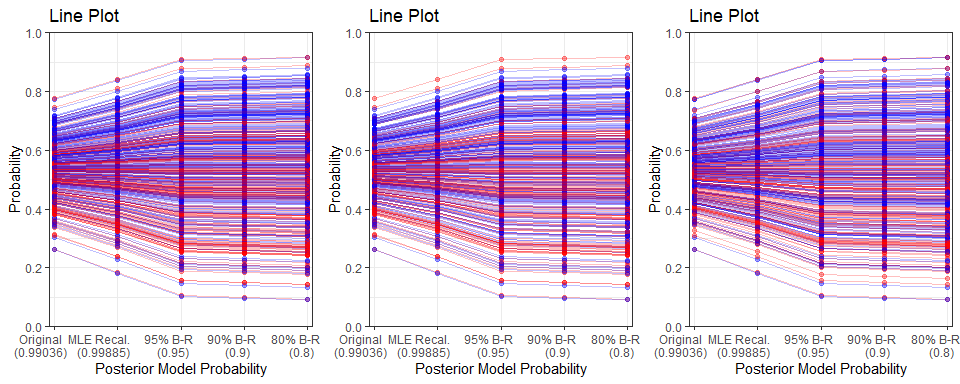

```r
lp1 <- lineplot(df=lp$df, t_levels=c(0.95, 0.9, 0.8), thin_to=500)
lp2 <- lineplot(df=lp$df, t_levels=c(0.95, 0.9, 0.8), thin_prop=0.5)
lp3 <- lineplot(df=lp$df, t_levels=c(0.95, 0.9, 0.8), thin_by=2)
gridExtra::grid.arrange(lp1, lp2, lp3, ncol=3)
```

By default, there is a seed set so that the observations selected stay the same through successive calls using the same thinning strategy. To change the seed, users can specify their own via `seed`. Notice in the example below that we’re using the same strategy as panel one in the above set of plots but the points are slightly different.

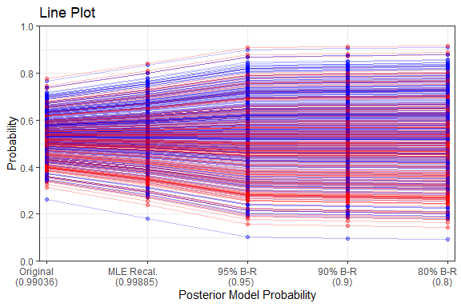

```r
lineplot(df=lp$df, t_levels=c(0.95, 0.9, 0.8), thin_to=500, seed = 47)
```

Alternatively, if users would prefer no seed be set, they can set `seed=NULL`. In the plot below, we again have a different set of points and lines. In fact, each compilation of this vignette will have a different set.

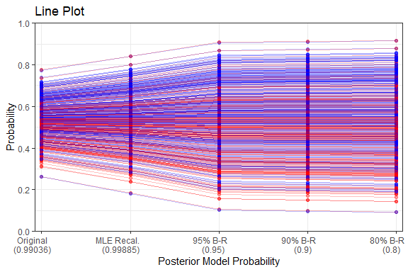

```r
lineplot(df=lp$df, t_levels=c(0.95, 0.9, 0.8), thin_to=500, seed=NULL)
```

### Passing Additional Arguments to `optim` and `nloptr`

Similar to the `plot_params` function, this function allows users to specify additional arguments to `optim` via `optim_options`. Additionally, we also allow users to pass arguments to `nloptr` via `nloptr_options` in a similar fashion. In this case, the list passed via `nloptr_options` is passed to `opts` in the `brcal` function. For more information on how to structure this list, see Passing Additional / Different Arguments to `nloptr()`.

# References

Birgin, Ernesto G., and José Mario Martínez. 2008. “Improving Ultimate Convergence of an Augmented Lagrangian Method.” *Optimization Methods and Software* 23: 177–95. https://doi.org/10.1080/10556780701577730.

Conn, Andrew R., Nicholas I. M. Gould, and Philippe L. Toint. 1991. “A Globally Convergent Augmented Lagrangian Algorithm for Optimization with General Constraints and Simple Bounds.” *SIAM J. Numer. Anal.* 28 (2): 545–72. https://doi.org/10.1137/0728030.

FiveThirtyEight. 2021. “2020-21 NHL Predictions.” fivethirtyeight.com. https://data.fivethirtyeight.com/.

Guthrie, Adeline P., and Christopher T. Franck. 2024. “Boldness-Recalibration for Binary Event Predictions.” *The American Statistician* 0 (0): 1–11. https://doi.org/10.1080/00031305.2024.2339266.

Johnson, Steven G. 2007. “The NLopt Nonlinear-Optimization Package.” https://github.com/stevengj/nlopt.

Kraft, Dieter. 1988. *A Software Package for Sequential Quadratic Programming*. Deutsche Forschungs- Und Versuchsanstalt für Luft- Und Raumfahrt köln: Forschungsbericht. Wiss. Berichtswesen d. DFVLR. https://books.google.com/books?id=4rKaGwAACAAJ.

———. 1994. “Algorithm 733: TOMP–Fortran Modules for Optimal Control Calculations.” *ACM Trans. Math. Softw.* 20 (3): 262–81. https://doi.org/10.1145/192115.192124.

Nelder, J. A., and R. Mead. 1965. “A Simplex Method for Function Minimization.” *The Computer Journal* 7 (4): 308–13. https://doi.org/10.1093/comjnl/7.4.308.

Svanberg, Krister. 2002. “A Class of Globally Convergent Optimization Methods Based on Conservative Convex Separable Approximations.” *SIAM Journal on Optimization* 12 (January): 555–73. https://doi.org/10.1137/S1052623499362822.